# Effects of tool use and perturbation during motor adaptation on hand localization in immersive virtual reality

Maryum Khan

Load packages

# Reach to Target

## Hand (Experiment 1)

Load data

```r
hand_data <- read.csv("omnibus_hand.csv")
#ppid from int to chr
hand_data$ppid <- as.character(hand_data$ppid)

##Aligned session
#Filter last 3 blocks of aligned hand reaches and add summary statistics
aligned_hand <- hand_data %>%
  filter(type=='aligned', block_num > 19)%>%
  mutate(type = 'aligned_hand') %>%
  group_by(experiment, type, trial_num)%>%
  summarise(aligned_mean=mean(deviation, na.rm = TRUE),
            reaches_median=median(deviation, na.rm = TRUE),
            sd_err = sd(deviation, na.rm = TRUE),
            n=n(),.groups = 'drop') %>%
  mutate(lower_ci = reaches_median - qt(1 - (0.05/2), n - 1) * (sd_err / sqrt(n)),
         upper_ci = reaches_median + qt(1 - (0.05/2), n - 1) * (sd_err / sqrt(n)))

#reorder the aligned trials so they appear in sequence
aligned_hand$sequential_trials <- 1:(nrow(aligned_hand))

##Rotated session
#Filter first 100 rotated hand reaches and add summary statistics
#Deviation = cursor_3cm_out_angle - target_angle
rotated_hand <- hand_data %>%
  filter(type=='rotated', block_num < 30)%>%
  mutate(type = 'rotated_hand') %>%
  group_by(experiment, type, trial_num)%>%
  summarise(rotated_mean=mean(deviation, na.rm = TRUE),
            reaches_median=median(deviation, na.rm = TRUE),
            sd_err = sd(deviation, na.rm = TRUE),
            n=n(),.groups = 'drop') %>%
  mutate(lower_ci = reaches_median - qt(1 - (0.05/2), n - 1) * (sd_err / sqrt(n)),
         upper_ci = reaches_median + qt(1 - (0.05/2), n - 1) * (sd_err / sqrt(n)))

# Re-number the trial numbers starting from 1
rotated_hand$sequential_trials <- 1:(nrow(rotated_hand))
rotated_hand$sequential_trials <- rotated_hand$sequential_trials + 26
```

## Pen (Experiment 2)

Load aligned data

```r
data_toola <- "pen_aligned.csv"
pen_data <- fread(data_toola)
#ppid from int to chr
hand_data$ppid <- as.character(hand_data$ppid)

#Filter last 3 blocks of aligned pen reaches (deviation = pen_3cm_out_angle - target angle )
aligned_pen <- pen_data %>%
  filter(type=='aligned', block_num >43)%>%
  mutate(type = 'aligned_pen') %>%
  group_by(experiment, type, trial_num)%>%
  summarise(aligned_mean=mean(deviation, na.rm = TRUE),
            reaches_median=median(deviation, na.rm = TRUE),
            sd_err = sd(deviation, na.rm = TRUE),
            n=n(),.groups = 'drop') %>%
  mutate(lower_ci = reaches_median - qt(1 - (0.05/2), n - 1) * (sd_err / sqrt(n)),
         upper_ci = reaches_median + qt(1 - (0.05/2), n - 1) * (sd_err / sqrt(n)))

# Create a new variable with consecutive trial numbers
aligned_pen$sequential_trials <- 1:(nrow(aligned_pen))

#ROTATED
#Pen Rotated reaches first 100 trials
data_toolhand <- "pen_rotated.csv"
pen_train <- fread(data_toolhand)
```

Load rotated data

```r
#ROTATED filter first 100 trials
#deviation = pen_3cm_out_angle - target_angle
rotated_pen <- pen_train %>%
  filter(type=='rotated', block_num < 3) %>%
  mutate(type = 'rotated_pen') %>%
  group_by(experiment, type, trial_num)%>%
  summarise(rotated_mean=mean(deviation,na.rm = TRUE),
            reaches_median=median(deviation,na.rm = TRUE),
            sd_err = sd(deviation, na.rm = TRUE),
            n=n(),.groups = 'drop') %>%
  mutate(lower_ci = reaches_median - qt(1 - (0.05/2), n - 1) * (sd_err / sqrt(n)),
         upper_ci = reaches_median + qt(1 - (0.05/2), n - 1) * (sd_err / sqrt(n)))

# Re-number the trial numbers starting from 1
rotated_pen$sequential_trials <- 1:(nrow(rotated_pen))
rotated_pen$sequential_trials <- rotated_pen$sequential_trials + 26

#ROTATED HAND REACHES AFTER TRAINING WITH PEN
data_toolhand <- "pen_rotated.csv"
pen_hand <- fread(data_toolhand)

rotated <- pen_hand %>%
  filter(type=='rotated', block_num > 46)

#rotated_diff <- rotated$hand_3cm_out_angle - rotated$target_angle
rotated$deviation <- rotated$hand_3cm_out_angle - rotated$target_angle
rotated <- rotated %>%
  mutate(type = 'rotated_hand_pen') %>%
  group_by(experiment, type, trial_num)%>%
  summarise(rotated_mean=mean(deviation, na.rm = TRUE),
            reaches_median=median(deviation, na.rm = TRUE),
            sd_err = sd(deviation, na.rm = TRUE),
            n=n(),.groups = 'drop') %>%
  mutate(lower_ci = reaches_median - qt(1 - (0.05/2), n - 1) * (sd_err / sqrt(n)),
         upper_ci = reaches_median + qt(1 - (0.05/2), n - 1) * (sd_err / sqrt(n)))

# Re-number the trial numbers starting from 1
rotated$sequential_trials <- 1:(nrow(rotated))
rotated$sequential_trials <- rotated$sequential_trials + 130
```

Now that all variables have been defined, plot learning by combining all trial types

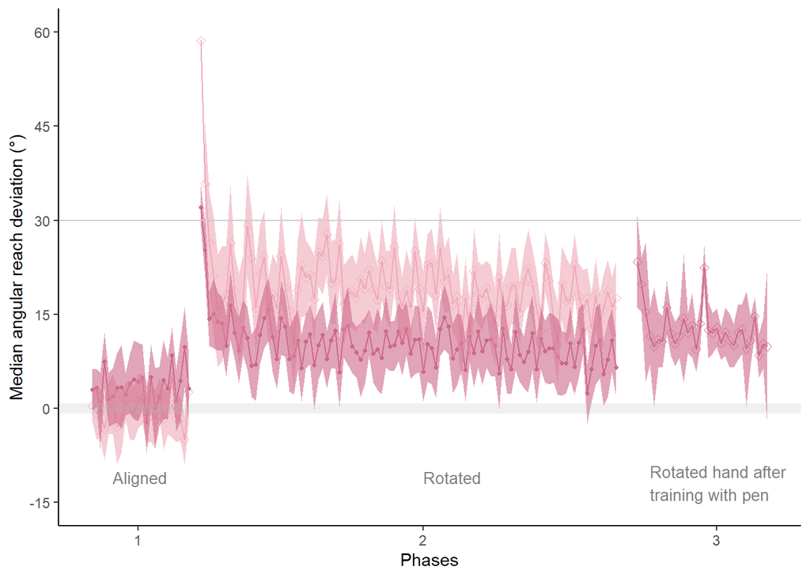

```r
# Combine aligned and rotated datasets into one for ribbon
combined_ribbons <- bind_rows(
  mutate(aligned_hand, source = "hand"),
  mutate(aligned_pen, source = "pen"),
  mutate(rotated_hand, source = "hand"),
  mutate(rotated_pen, source = "pen"),
  mutate(rotated, source = "hand")
)

#Plot learning
reaches <- ggplot(combined_ribbons, aes(x = sequential_trials, y = reaches_median,
                                        color = type, fill = type, shape = type)) +
  geom_point() +
  geom_line() +
  geom_ribbon(aes(ymin = lower_ci, ymax = upper_ci), alpha = 0.6, color = NA)

#Change point shape to differentiate between hand and pen trial types and adjust colors
reaches <- reaches +
  scale_shape_manual(values = c("aligned_hand" = 5, "rotated_hand" = 5,
                                "aligned_pen" = 20, "rotated_pen" = 20, "rotated_hand_pen" = 5))+
  scale_color_manual(values = c("aligned_hand" = "pink2", "aligned_pen" = "palevioletred3",
                                "rotated_hand" = "pink2", "rotated_pen" = "palevioletred3",
                                "rotated_hand_pen" = "palevioletred3")) +
  scale_fill_manual(values = c("aligned_hand" = "pink2", "aligned_pen" = "palevioletred3",
                               "rotated_hand" = "pink2", "rotated_pen" = "palevioletred3",
                               "rotated_hand_pen" = "palevioletred3"))

#Adjust x and y axis and add horizontal lines
reaches <- reaches +
  theme_classic()+
  theme(legend.position = "none")+
  geom_hline(
    yintercept = 30, linewidth = 0.4,
    colour = "#CCCCCC", linetype = "solid"
  )+
  geom_hline(
    yintercept = 0, linewidth = 3.0,
    colour = "gray70", linetype = "solid", alpha = 0.2
  )+
  theme(text = element_text(size = 11))+
  labs(
    x = "Phases",
    y = "Median angular reach deviation (°)"
    )+
  scale_y_continuous(
    limits = c(-15, 60),
    breaks = c(0, -15, 15, 30, 45, 60),
    labels = c(0, -15, 15, 30, 45, 60)
  )+
  scale_x_continuous(
    breaks = c(12, 80, 150),
    labels = c(1, 2, 3)
  )+
  annotate("text", x = 6, y = -10, hjust = 0, vjust = 1,
           label = "Aligned", color = "gray50", size = 3.5)+
  annotate("text", x = 80, y = -10, hjust = 0, vjust = 1,
           label = "Rotated", color = "gray50", size = 3.5)+
  annotate("text", x = 134, y = -9, hjust = 0, vjust = 1,
           label = "Rotated hand after\ntraining with pen", color = "gray50", size = 3.5)

print(reaches)
```

The y-axis represents the median angular reach deviation which was calculated by subtracting target angle from the hand/pen 3cm out angle (peak velocity). Phase 1 = last 3 sets (24 trials) for the aligned session. Phase 2 = first 100 rotated trials Phase 3 = 32 trials from rotated hand after training with the pen

# No Cursor/No Pen Reaches

## Hand (Experiment 1)

No Cursor Load data

```r
#Filter df for only nocursor trials and exclude practice block
data <- hand_data %>%
 filter(type=="nocursor", block_num >7)
#Create subtype to differentiate between no cursor trials before and after training
NoCursor <- data %>%
  mutate(nocursor_type = case_when(
    trial_num <= 191 ~ "aligned hand",
    trial_num >= 343 ~ "rotated hand"))
#Calculate the angular reach deviation by subtracting endpoint and target angle
nocursor_diff <- (NoCursor$hand_final_angle - NoCursor$target_angle)*(-1)
NoCursor$nocursor_diff <- nocursor_diff

#Summary statistics
nocursor_summary <- NoCursor %>%
  group_by(ppid,nocursor_type) %>%
  summarise(nocursor_median = median(nocursor_diff, na.rm = TRUE),
            nocursor_mean = mean(nocursor_diff, na.rm = TRUE),
            nocursor_sd = sd(nocursor_diff, na.rm = TRUE))
#Identify and remove outliers
filtered_nhand <- NoCursor %>%
  left_join(nocursor_summary, by = c("ppid", "nocursor_type")) %>%
  mutate(
    is_outlier = nocursor_diff > nocursor_mean + 3 * nocursor_sd | nocursor_diff < nocursor_mean - 3 * nocursor_sd
  ) %>%
  filter(!is_outlier) %>%
  select(-is_outlier)
# Identify outliers from the original Localization dataframe
outliers_nhand <- NoCursor %>%
  left_join(nocursor_summary, by = c("ppid", "nocursor_type")) %>%
  filter(nocursor_diff > nocursor_mean + 3 * nocursor_sd | nocursor_diff < nocursor_mean - 3 * nocursor_sd) %>%
  select(-nocursor_median, -nocursor_mean, -nocursor_sd)
```

Now that we’ve calculated the medians, plot angular reach deviations during no cursor

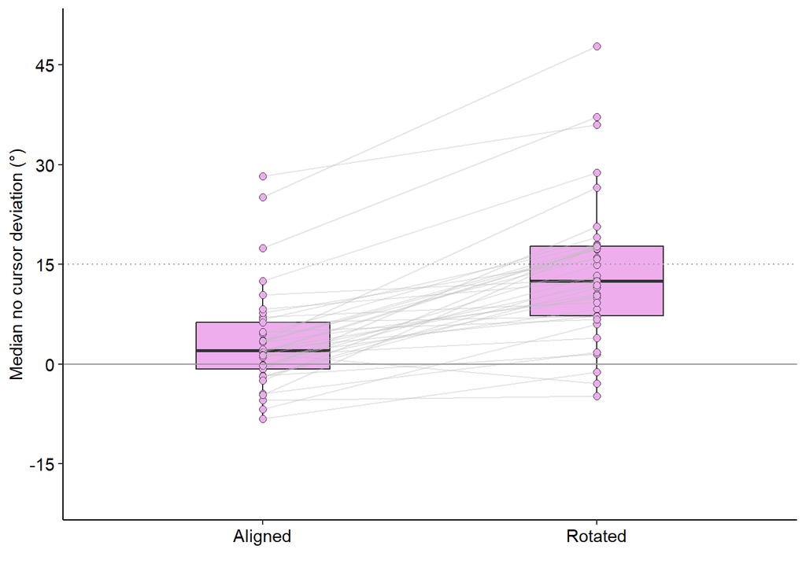

```r
hand_nocursor <- filtered_nhand %>%
  ggplot(aes(x=nocursor_type, y=nocursor_median, fill=nocursor_type))+
  geom_boxplot(width=0.4)+
  geom_point(aes(fill=nocursor_type),size=2,shape=21, alpha=0.5)+
  geom_line(aes(group=ppid), color='gray', alpha=0.4)+
  theme_classic()+
#Select custom bar colors
  scale_color_manual(values = c("aligned hand"="plum2", "rotated hand"="plum2", alpha = 0.9))+
  scale_fill_manual(values = c("aligned hand"="plum2", "rotated hand"="plum2", alpha = 0.9))+
#Adjust plot layout, font size, x and y axis
  theme(
    legend.position="none",
    axis.text = element_text(size = 11),
    axis.title.y = element_text(size = 11)
  ) +
  xlab("")+
  ylab("Median no cursor deviation (°)")+
  geom_hline(
    yintercept = c(0), linewidth = 0.4,
    colour = "#999999", linetype = "solid"
  ) +
  geom_hline(
    yintercept = c(15), linewidth = 0.4,
    colour = "#999999", linetype = "dotted"
  ) +
    scale_x_discrete(labels = c("aligned hand" = "Aligned", "rotated hand" = "Rotated"))+
  scale_y_continuous(
    limits = c(-20, 50),
    breaks = c(0, -15, 15, 30, 45),
    labels = c(0, -15, 15, 30, 45)
  )+
  theme(text = element_text(size = 11))+
  theme(axis.text.x = element_text(color = "black"))+
  theme(axis.text.y = element_text(color = "black"))

print(hand_nocursor)
```

### Statistical Analyses

Run paired t-tests to check for significance between no cursor reaches before and after training

```r
#Comparison stats
#paired t-test
naligned_group <- nocursor_summary %>%
  filter(nocursor_type == "aligned hand") %>%
  pull(nocursor_mean)

nrotated_group <- nocursor_summary %>%
  filter(nocursor_type == "rotated hand") %>%
  pull(nocursor_mean)

ndiffs <- nrotated_group - naligned_group
t.test(ndiffs)
```

```
##
##  One Sample t-test
##
## data:  ndiffs
## t = 9.7091, df = 37, p-value = 1.019e-11
## alternative hypothesis: true mean is not equal to 0
## 95 percent confidence interval:
##   8.696949 13.284183
## sample estimates:
## mean of x
##  10.99057
```

## Pen (Experiment 2)

No Pen/ No Cursor Since aligned and rotated sessions were part of two jsons, start off by loading aligned sessions and create new dataframe

```r
#Load aligned session data and filter for only nocursor trials and exclude practice block
data_toola <- "pen_aligned.csv"
A_NoCursor_pen <- fread(data_toola)%>%
  filter(type=="nocursor", block_num >8)
#Create subtypes to differentiate between no cursor and no pen reaches before training
A_NoCursor_pen <- A_NoCursor_pen %>%
  mutate(nocursor_type = case_when(
    block_num %in% c(21,36,51) ~ "aligned pen",
    block_num %in% c(18,33,48) ~ "aligned hand",
    TRUE ~ "other"),
  nocursor_diff = case_when(
    nocursor_type == "aligned pen" ~ pen_final_angle - target_angle,
    nocursor_type == "aligned hand" ~ hand_final_angle - target_angle))
#Summary statistics
A_NoCursor_summary <- A_NoCursor_pen %>%
  group_by(ppid,nocursor_type) %>%
  summarise(nocursor_median = median(nocursor_diff, na.rm = TRUE),
            nocursor_mean = mean(nocursor_diff, na.rm = TRUE),
            nocursor_sd = sd(nocursor_diff, na.rm = TRUE))
#Identify and remove outliers
filtered_npen <- A_NoCursor_pen %>%
  left_join(A_NoCursor_summary, by = c("ppid", "nocursor_type")) %>%
  mutate(
    is_outlier = nocursor_diff > nocursor_mean + 3 * nocursor_sd | nocursor_diff < nocursor_mean - 3 * nocursor_sd
  ) %>%
  filter(!is_outlier) %>%
  select(-is_outlier)
# Identify outliers from the original Localization dataframe
outliers_npen <- A_NoCursor_pen %>%
  left_join(A_NoCursor_summary, by = c("ppid", "nocursor_type")) %>%
  filter(nocursor_diff > nocursor_mean + 3 * nocursor_sd | nocursor_diff < nocursor_mean - 3 * nocursor_sd) %>%
  select(-nocursor_median, -nocursor_mean, -nocursor_sd)
```

Load data from rotated session

```r
#Load rotated session data and filter for only nocursor trials and exclude practice block
data_penr <- "pen_rotated.csv"
Rnocursor_pen <- fread(data_penr)%>%
  filter(type=="nocursor")
#Create new subtypes and calculate angular reach deviation
Rnocursor_pen <- Rnocursor_pen %>%
  mutate(nocursor_type = case_when(
    block_num %in% c(15,30,45) ~ "rotated pen",
    block_num %in% c(12,27,42) ~ "rotated hand",
    block_num %in% c(50) ~ "rotated hand-pen"),
    nocursor_diff = case_when(
      nocursor_type == "rotated pen" ~ (pen_final_angle - target_angle)*(-1),
      nocursor_type == "rotated hand" ~ (hand_final_angle - target_angle)*(-1),
      nocursor_type == "rotated hand-pen" ~ (hand_final_angle - target_angle)*(-1)))
#Summary statistics
Rnocursor_summary <- Rnocursor_pen %>%
  group_by(ppid,nocursor_type) %>%
  summarise(nocursor_median = median(nocursor_diff),
            nocursor_mean = mean(nocursor_diff),
            nocursor_sd = sd(nocursor_diff))
#Identify and remove outliers
filtered_nrpen <- Rnocursor_pen %>%
  left_join(Rnocursor_summary, by = c("ppid", "nocursor_type")) %>%
  mutate(
    is_outlier = nocursor_diff > nocursor_mean + 3 * nocursor_sd | nocursor_diff < nocursor_mean - 3 * nocursor_sd
  ) %>%
  filter(!is_outlier) %>%
  select(-is_outlier)
# Identify outliers from the original Localization dataframe
outliers_nrpen <- Rnocursor_pen %>%
  left_join(Rnocursor_summary, by = c("ppid", "nocursor_type")) %>%
  filter(nocursor_diff > nocursor_mean + 3 * nocursor_sd | nocursor_diff < nocursor_mean - 3 * nocursor_sd) %>%
  select(-nocursor_median, -nocursor_mean, -nocursor_sd)
```

Plot no cursor and no pen reaches with individual data

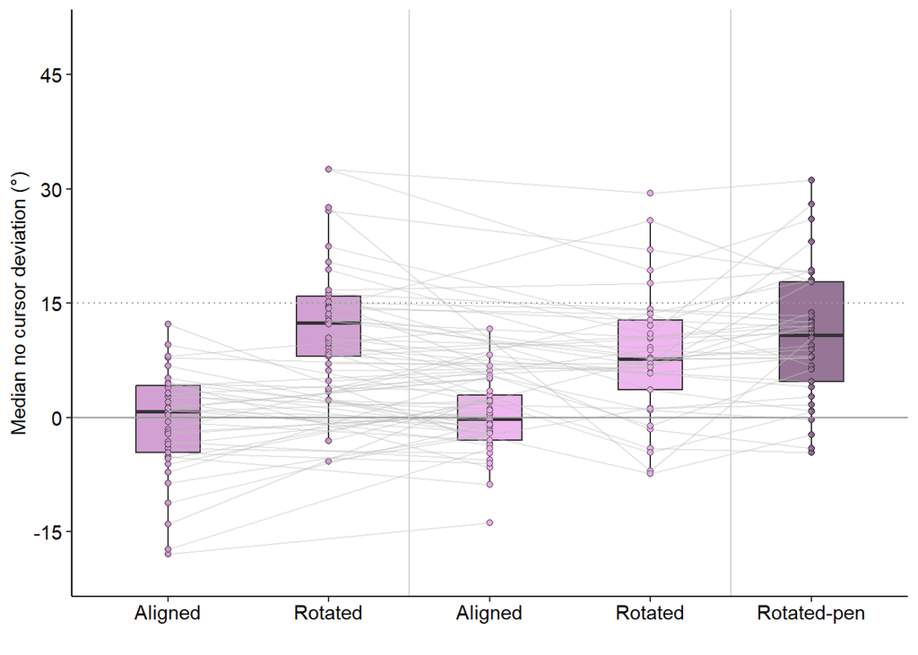

```r
#Combine aligned and rotated data
combined_dataset <- rbind(filtered_npen, filtered_nrpen)
#Reorder the order of bars displayed on the plot
order_of_bars <- c("aligned pen", "rotated pen", "aligned hand", "rotated hand", "rotated hand-pen")
combined_dataset$category <- factor(combined_dataset$nocursor_type, levels = order_of_bars)
#Assign custom colors to the bars
bar_colors <- c("plum2","plum3","plum2","plum4","plum3")
#Plot using ggplot
Combine_nocursor <- combined_dataset %>%
  ggplot(aes(x=category, y=nocursor_median, fill=nocursor_type))+
  geom_boxplot(width = 0.4)+
  geom_point(aes(fill=category),size=1.5,shape=21, alpha=0.5)+
  geom_line(aes(group=ppid), color='gray', alpha=0.4)+
  scale_fill_manual(values = alpha(bar_colors, alpha=0.9))+
#Format plot by adding lines, adjusting font size, and x and y axis
  theme_classic()+
  geom_hline(
    yintercept = c(0), linewidth = 0.4,
    colour = "#999999", linetype = "solid"
  ) +
  geom_hline(
    yintercept = c(15), linewidth = 0.4,
    colour = "#999999", linetype = "dotted"
  ) +
  xlab("")+
  ylab("Median no cursor deviation (°)")+
  geom_vline(xintercept = c(2.5), color = "light gray", linetype = "solid", size = 0.5) +
  geom_vline(xintercept = c(4.5), color = "light gray", linetype = "solid", size = 0.5) +
  scale_x_discrete(labels=c('Aligned', 'Rotated', 'Aligned','Rotated', 'Rotated-pen'))+
  theme(
    legend.position="none",
    axis.text = element_text(size = 11),
    axis.title.y = element_text(size = 11)
  ) +
  theme(axis.text.x = element_blank())+
  scale_y_continuous(
    limits = c(-20, 50),
    breaks = c(0, -15, 15, 30, 45),
    labels = c(0, -15, 15, 30, 45)
  )+
  theme(text = element_text(size = 11))+
  theme(axis.text.x = element_text(color = "black"))+
  theme(axis.text.y = element_text(color = "black"))
print(Combine_nocursor)
```

### Statistical analyses

Run paired t-tests between aligned and rotated to check for significance between the two types among the different groups

```r
#Comparison stats
#paired t-test
rotated_hand <- Rnocursor_summary %>%
  filter(nocursor_type == "rotated hand") %>%
  pull(nocursor_median)

rotated_pen <- Rnocursor_summary %>%
  filter(nocursor_type == "rotated pen") %>%
  pull(nocursor_median)

aligned_hand <- A_NoCursor_summary %>%
  filter(nocursor_type == "aligned hand") %>%
  pull(nocursor_median)

aligned_pen <- A_NoCursor_summary %>%
  filter(nocursor_type == "aligned pen") %>%
  pull(nocursor_median)

#t-test for hand no cursor in pen trials
diffs_hand <- rotated_hand - aligned_hand
t.test(diffs_hand)
```

```
##
##  One Sample t-test
##
## data:  diffs_hand
## t = 4.1045, df = 37, p-value = 0.0002141
## alternative hypothesis: true mean is not equal to 0
## 95 percent confidence interval:
##   4.161732 12.276344
## sample estimates:
## mean of x
##  8.219038
```

```r
#t-test for pen no cursor in pen trials
diffs_pen <- rotated_pen - aligned_pen
t.test(diffs_pen)
```

```
##
##  One Sample t-test
##
## data:  diffs_pen
## t = 6.0666, df = 37, p-value = 5.102e-07
## alternative hypothesis: true mean is not equal to 0
## 95 percent confidence interval:
##   8.744347 17.514657
## sample estimates:
## mean of x
##   13.1295
```

# Localization

## Hand (Experiment 1)

Hand Localization Since aligned and rotated sessions were part of two jsons, start off by loading aligned sessions and create new dataframe by filtering for only localization trials

```r
#filter for localization trials and exclude practice trials
localization <- hand_data %>%
  filter(type=="localization")%>%
  filter(!(trial_num >= 19 & trial_num <= 26))
#Create new subtype to differentiate between aligned and rotated trials
Localization <- localization %>%
  mutate(localization_type = case_when(
    trial_num < 191 ~ "aligned hand",
    trial_num > 194 ~ "rotated hand"))
#Calculate change in localization
local_arc_acqr <- Localization$localizing_angle - Localization$arc_aquired_angle
Localization$local_diff <- local_arc_acqr
#Summary statistics
localization_summary <- Localization %>%
  group_by(ppid,localization_type) %>%
  summarise(local_median = median(local_diff, na.rm = TRUE),
            local_mean = mean(local_diff, na.rm = TRUE),
            local_sd = sd(local_diff, na.rm = TRUE))
#Identify and remove outlier trials
filtered_data <- Localization %>%
  left_join(localization_summary, by = c("ppid", "localization_type")) %>%
  mutate(
    is_outlier = local_diff > local_mean + 3 * local_sd | local_diff < local_mean - 3 * local_sd
  ) %>%
  filter(!is_outlier) %>%
  select(-is_outlier)
# Identify outliers from the original Localization dataframe
outliers <- Localization %>%
  left_join(localization_summary, by = c("ppid", "localization_type")) %>%
  filter(local_diff > local_mean + 3 * local_sd | local_diff < local_mean - 3 * local_sd) %>%
  select(-local_median, -local_mean, -local_sd)
filtered_data %>%
  group_by(localization_type) %>%
  summarise(num_points = n())
```

```
## # A tibble: 2 × 2
##   localization_type num_points
##   <chr>                  <int>
## 1 aligned hand            1820
## 2 rotated hand            1819
```

Plot hand localization

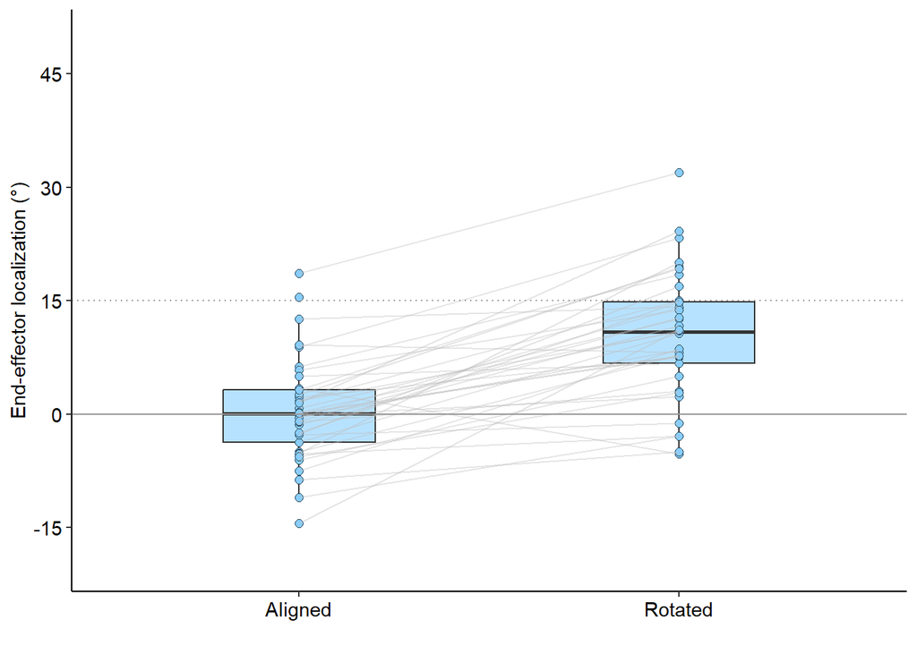

```r
hand_localization <- filtered_data %>%
  ggplot(aes(x=localization_type, y=local_median, fill=localization_type))+
  geom_boxplot(width=0.4, alpha = 0.6)+
  geom_point(aes(fill=localization_type),size=2,shape=21, alpha=0.5)+
  geom_line(aes(group=ppid), color='gray', alpha=0.4)+
  theme_classic()+
  scale_color_manual(values = c("aligned hand"="skyblue1", "rotated hand"="skyblue1"))+
  scale_fill_manual(values = c("aligned hand"="skyblue1", "rotated hand"="skyblue1"))+
  theme(
    legend.position="none",
    axis.text = element_text(size = 11),
    axis.title.y = element_text(size = 11)
  ) +
  xlab("")+
  ylab("End-effector localization (°)")+
  geom_hline(
    yintercept = c(0), linewidth = 0.4,
    colour = "#999999", linetype = "solid"
  ) +
  geom_hline(
    yintercept = c(15), linewidth = 0.4,
    colour = "#999999", linetype = "dotted"
  ) +
  scale_x_discrete(labels = c("aligned hand" = "Aligned", "rotated hand" = "Rotated"))+
  scale_y_continuous(
    limits = c(-20, 50),
    breaks = c(0, -15, 15, 30, 45),
    labels = c(0, -15, 15, 30, 45)
  )+
  theme(text = element_text(size = 11))+
  theme(axis.text.x = element_text(color = "black"))+
  theme(axis.text.y = element_text(color = "black"))

print(hand_localization)
```

### Statistical Analysis

Perform paired t-test to determine if there are significant changes in localization after training

```r
#Comparison stats
#paired t-test
aligned_group <- localization_summary %>%
  filter(localization_type == "aligned hand") %>%
  pull(local_median)

rotated_group <- localization_summary %>%
  filter(localization_type == "rotated hand") %>%
  pull(local_median)

diffs <- rotated_group - aligned_group
t.test(diffs)
```

```
##
##  One Sample t-test
##
## data:  diffs
## t = 8.1387, df = 37, p-value = 9.138e-10
## alternative hypothesis: true mean is not equal to 0
## 95 percent confidence interval:
##   8.353485 13.891532
## sample estimates:
## mean of x
##  11.12251
```

## Pen (Experiment 2)

Pen and hand localization Aligned Session

```r
#Filter for only localization trials and exclude practice
data_toola <- read.csv("pen_aligned.csv")
Alocalization_pen <- data_toola %>%
  filter(type=="localization", block_num >8)
#Calculate change in localization
local_diff <- Alocalization_pen$localizing_angle - Alocalization_pen$arc_aquired_angle
Alocalization_pen$local_diff <- Alocalization_pen$localizing_angle - Alocalization_pen$arc_aquired_angle
#Create new subtype to differentiate pen and hand trials
Alocalization_pen <- Alocalization_pen %>%
    mutate(localization_type = case_when(
    block_num %in% c(9,13,24,28,39,43) ~ "aligned pen",
    block_num %in% c(11,15,26,30,41,45) ~ "aligned hand",
    TRUE ~ "other"
  ))
#Summary statistics
Alocalization_sum <- Alocalization_pen %>%
  group_by(ppid,localization_type) %>%
  summarise(local_median = median(local_diff, na.rm = TRUE),
            local_mean = mean(local_diff, na.rm = TRUE),
            local_sd = sd(local_diff, na.rm = TRUE))
#Identify and remove outliers
filtered_alignedpen <- Alocalization_pen %>%
  left_join(Alocalization_sum, by = c("ppid", "localization_type")) %>%
  mutate(
    is_outlier = local_diff > local_mean + 3 * local_sd | local_diff < local_mean - 3 * local_sd
  ) %>%
  filter(!is_outlier) %>%
  select(-is_outlier)
# Identify outliers from the original Localization dataframe
outliers <- Alocalization_pen %>%
  left_join(Alocalization_sum, by = c("ppid", "localization_type")) %>%
  filter(local_diff > local_mean + 3 * local_sd | local_diff < local_mean - 3 * local_sd) %>%
  select(-local_median, -local_mean, -local_sd)
```

Rotated session

```r
#Filter for localization trials
data_penr <- read.csv("pen_rotated.csv")
Rlocalization_pen <- data_penr %>%
  filter(type=="localization")
#Calculate change in localization
local_diff <- Rlocalization_pen$localizing_angle - Rlocalization_pen$arc_aquired_angle
Rlocalization_pen$local_diff <- Rlocalization_pen$localizing_angle - Rlocalization_pen$arc_aquired_angle
#Create subtype to differentiate between hand and pen trials
Rlocalization_pen <- Rlocalization_pen %>%
  mutate(localization_type = case_when(
    block_num %in% c(3,7,18,22,33,37) ~ "rotated pen",
    block_num %in% c(5,9,20,24,35,39) ~ "rotated hand",
    block_num %in% c(48) ~ "rotated pen hand",
    TRUE ~ "other"
  ))
#Summary statistics
Rlocalization_summary <- Rlocalization_pen %>%
  group_by(ppid,localization_type) %>%
  summarise(local_median = median(local_diff, na.rm = TRUE),
            local_mean = mean(local_diff, na.rm = TRUE),
            local_sd = sd(local_diff, na.rm = TRUE))
#Identify and remove outliers
filtered_rotatedpen <- Rlocalization_pen %>%
  left_join(Rlocalization_summary, by = c("ppid", "localization_type")) %>%
  mutate(
    is_outlier = local_diff > local_mean + 3 * local_sd | local_diff < local_mean - 3 * local_sd
  ) %>%
  filter(!is_outlier) %>%
  select(-is_outlier)
# Identify outliers from the original Localization dataframe
outliers <- Rlocalization_pen %>%
  left_join(Rlocalization_summary, by = c("ppid", "localization_type")) %>%
  filter(local_diff > local_mean + 3 * local_sd | local_diff < local_mean - 3 * local_sd) %>%
  select(-local_median, -local_mean, -local_sd)
```

Combine both dataframes and plot Experiment 2 boxplots on one

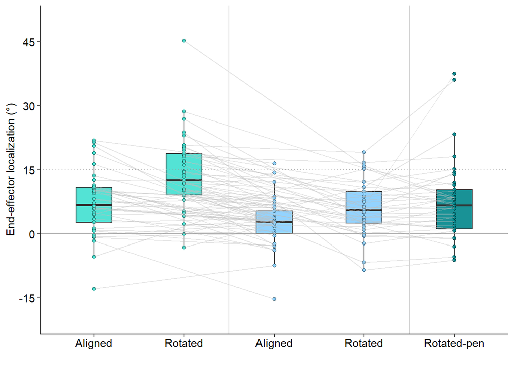

```r
combined_dataset <- rbind(filtered_alignedpen, filtered_rotatedpen)
order_of_bars <- c("aligned pen", "rotated pen", "aligned hand", "rotated hand", "rotated pen hand")
combined_dataset$category <- factor(combined_dataset$localization_type, levels = order_of_bars)

#Plot using ggplot and geom_boxplot
bar_colors <- c("skyblue1","turquoise","skyblue1","turquoise","turquoise4")
Combine_localization <- combined_dataset %>%
  ggplot(aes(x=category, y=local_median, fill=localization_type))+
  geom_boxplot(width=0.4)+
  geom_point(aes(fill=category),size=1.5,shape=21, alpha=0.5)+
  geom_line(aes(group=ppid), color='gray', alpha=0.4)+
  scale_fill_manual(values = alpha(bar_colors, alpha=0.9))+
  theme_classic()+
  geom_hline(
    yintercept = c(0), linewidth = 0.4,
    colour = "#999999", linetype = "solid"
  ) +
  geom_hline(
    yintercept = c(15), linewidth = 0.4,
    colour = "#999999", linetype = "dotted"
  ) +
  xlab("")+
  ylab("End-effector localization (°)")+
  geom_vline(xintercept = c(2.5), color = "light gray", linetype = "solid", size = 0.5) +
  geom_vline(xintercept = c(4.5), color = "light gray", linetype = "solid", size = 0.5) +
  scale_x_discrete(labels=c('Aligned', 'Rotated', 'Aligned','Rotated', 'Rotated-pen'))+
  theme(
    legend.position="none",
    axis.text = element_text(size = 11),
    axis.title.y = element_text(size = 11)
  ) +
  # theme(axis.ticks.x = element_blank())+
  theme(axis.text.x = element_blank())+
  scale_y_continuous(
    limits = c(-20, 50),
    breaks = c(0, -15, 15, 30, 45),
    labels = c(0, -15, 15, 30, 45)
  )+
  theme(text = element_text(size = 11))+
  theme(axis.text.x = element_text(color = "black"))+
  theme(axis.text.y = element_text(color = "black"))

print(Combine_localization)
```

### Statistical Analyses

Perform paired t-test to determine if there are significant changes in localization before and after training

```r
#Comparison stats
#paired t-test
rotated_hand <- Rlocalization_summary %>%
  filter(localization_type == "rotated hand") %>%
  pull(local_median)

rotated_pen <- Rlocalization_summary %>%
  filter(localization_type == "rotated pen") %>%
  pull(local_median)

aligned_hand <- Alocalization_sum %>%
  filter(localization_type == "aligned hand") %>%
  pull(local_median)

aligned_pen <- Alocalization_sum %>%
  filter(localization_type == "aligned pen") %>%
  pull(local_median)

#t-test for hand localization in pen trials
diffs_hand <- rotated_hand - aligned_hand
t.test(diffs_hand)
```

```
##
##  One Sample t-test
##
## data:  diffs_hand
## t = 2.953, df = 37, p-value = 0.00544
## alternative hypothesis: true mean is not equal to 0
## 95 percent confidence interval:
##  0.8648172 4.6460830
## sample estimates:
## mean of x
##   2.75545
```

```r
#t-test for pen localization in pen trials
diffs_pen <- rotated_pen - aligned_pen
t.test(diffs_pen)
```

```
##
##  One Sample t-test
##
## data:  diffs_pen
## t = 5.3073, df = 37, p-value = 5.44e-06
## alternative hypothesis: true mean is not equal to 0
## 95 percent confidence interval:
##  4.316690 9.648083
## sample estimates:
## mean of x
##  6.982387
```

# ANOVAS

Our main analyses will consists of three groups: training the hand in Experiment 1, training the pen in Experiment 2, and training the hand after training the pen in Experiment 2

## Reach-to-Target

```r
#ANOVA for rotated hand (Exp 1), rotated pen(Exp2), rotated hand after training with pen (Exp2)
#Exp1 rotated hand df for 3 trial sets (first, second, last)
handrot1 <- hand_data %>%
  filter(type == 'rotated' & between(trial_num, 194, 293) & !(between(trial_num, 202, 289))) %>%
  mutate(ppid = as.character(as.integer(ppid)))%>%
  mutate(trial_set = case_when(
    between(trial_num, 194, 197) ~ "1",
    between(trial_num, 198, 201) ~ "2",
    between(trial_num, 290, 293) ~ "3",
    TRUE ~ NA_character_
  ))

#Exp2 rotated pen
data_toolhand <- "pen_rotated.csv"
pen_rot <- fread(data_toolhand)
pen_rotated <- pen_rot %>%
  filter(between(trial_num, 2, 101) & !(between(trial_num, 10, 97))) %>%
  #mutate(ppid = as.character(as.integer(ppid)))%>%
  mutate(trial_set = case_when(
    between(trial_num, 2, 5) ~ "1",
    between(trial_num, 6, 9) ~ "2",
    between(trial_num, 98, 101) ~ "3",
    TRUE ~ NA_character_
  ))
pen_rotated <- pen_rotated %>%
  mutate(ppid = as.character(ppid))

#Exp2 rotated hand after training with pen
data_tool <- "pen_rotated.csv"
hand_trainpen <- fread(data_tool)
rotated_hand <- hand_trainpen %>%
  filter(type=='rotated'& between(trial_num, 391, 438) & !(between(trial_num, 399, 434))) %>%
  mutate(trial_set = case_when(
    between(trial_num, 391, 394) ~ "1",
    between(trial_num, 395, 398) ~ "2",
    between(trial_num, 435, 438) ~ "3",
    TRUE ~ NA_character_
  ))
handrot1$group <- 'hand'
pen_rotated$group <- 'pen'
rotated_hand$group <- 'hand_pen'

#Bind df rows to create one dataframe consisting of all three groups
filtered_data <- bind_rows(handrot1, pen_rotated, rotated_hand)
#Summary statistics
sum_stats <- filtered_data %>%
  mutate(diff = ifelse(!is.na(cursor_3cm_out_angle), cursor_3cm_out_angle - target_angle)) %>%
  bind_rows(
    pen_rotated %>%  # Calculate diff for pen_rotated dataframe
      mutate(diff = ifelse(pen_present, pen_3cm_out_angle - target_angle)),
    rotated_hand %>%  # Calculate diff for rotated_hand dataframe
      mutate(diff = hand_3cm_out_angle - target_angle))%>%
  filter(abs(diff) < 90)%>%
  group_by(ppid, group, trial_set) %>%
  summarise(median = median(diff, na.rm = TRUE))
#Perform a 3x3 ANOVA
anova_result <- aov(median ~ trial_set * group + Error(ppid/(trial_set * group)), data = sum_stats)
# Print the ANOVA summary
summary(anova_result)
```

```
##
## Error: ppid
##           Df Sum Sq Mean Sq F value   Pr(>F)
## group      1  16749   16749   52.78 3.14e-10 ***
## Residuals 74  23481     317
## ---
## Signif. codes:  0 '***' 0.001 '**' 0.01 '*' 0.05 '.' 0.1 ' ' 1
##
## Error: ppid:trial_set
##                  Df Sum Sq Mean Sq F value   Pr(>F)
## trial_set         2   9975    4987  43.757 1.18e-15 ***
## trial_set:group   2   1136     568   4.985  0.00803 **
## Residuals       148  16869     114
## ---
## Signif. codes:  0 '***' 0.001 '**' 0.01 '*' 0.05 '.' 0.1 ' ' 1
##
## Error: ppid:group
##           Df Sum Sq Mean Sq F value   Pr(>F)
## group      1   5279    5279   36.33 5.76e-07 ***
## Residuals 37   5375     145
## ---
## Signif. codes:  0 '***' 0.001 '**' 0.01 '*' 0.05 '.' 0.1 ' ' 1
##
## Error: ppid:trial_set:group
##                 Df Sum Sq Mean Sq F value  Pr(>F)
## trial_set:group  2    665   332.3   6.871 0.00183 **
## Residuals       74   3579    48.4
## ---
## Signif. codes:  0 '***' 0.001 '**' 0.01 '*' 0.05 '.' 0.1 ' ' 1
```

## No Cursor/ No Pen Reaches

```r
#EXPERIMENT 1 FOR HAND NOCURSOR
data_hand <- "omnibus_hand.csv"
nocursor <- fread(data_hand) %>%
  filter(type=="nocursor", block_num >7)

#filter the hand no cursors and create new cursor type and type
hand_nocur <- nocursor %>%
  mutate(type = case_when(
    trial_num <= 191 ~ "aligned",
    trial_num >= 343 ~ "rotated"))%>%
  mutate(ppid = as.character(as.integer(ppid))) %>%
  mutate(group = "hand") %>%
  mutate(deviation = hand_final_angle - target_angle)

#Summary statistics
hand_summary <- hand_nocur %>%
  group_by(ppid, type, group) %>%
  summarise(median = median(deviation, na.rm = TRUE),
            mean = mean(deviation, na.rm = TRUE),
            sd = sd(deviation, na.rm = TRUE))
#Identify and remove outliers
hand <- hand_nocur %>%
  left_join(hand_summary, by = c("ppid","type", "group")) %>%
  mutate(
    is_outlier = deviation > mean + 3 * sd | deviation < mean - 3 * sd
  ) %>%
  filter(!is_outlier) %>%
  select(-is_outlier)

#PEN ROTATED NO CURSOR
pen_aligned <- read.csv("pen_aligned.csv")
pen_rotated <- read.csv("pen_rotated.csv")
# Filter and add a "type" variable based on block numbers
aligned <- pen_aligned %>%
  filter(block_num %in% c(21, 36, 51)) %>%
  mutate(type = "aligned") %>%
  mutate(group = "pen")%>%
  mutate(deviation = pen_final_angle - target_angle)

rotated <- pen_rotated %>%
  filter(block_num %in% c(15, 30, 45)) %>%
  mutate(type = "rotated") %>%
  mutate(group = "pen")%>%
  mutate(deviation = pen_final_angle - target_angle)
#combine both dfs
pen_comb <- bind_rows(aligned, rotated)

#Summary statistics
pen_summary <- pen_comb %>%
  group_by(ppid, type, group) %>%
  summarise(median = median(deviation, na.rm = TRUE),
            mean = mean(deviation, na.rm = TRUE),
            sd = sd(deviation, na.rm = TRUE))
#Identify and remove outliers
pen <- pen_comb %>%
  left_join(pen_summary, by = c("ppid","type", "group")) %>%
  mutate(
    is_outlier = deviation > mean + 3 * sd | deviation < mean - 3 * sd
  ) %>%
  filter(!is_outlier) %>%
  select(-is_outlier)

#Hand after training with pen
aligned_hp <- pen_aligned %>%
  filter(block_num %in% c(18,33,48))%>%
  mutate(type = "aligned")%>%
  mutate(group = "hand_pen")%>%
  mutate(deviation = hand_final_angle - target_angle)

rotated_hp <- pen_rotated %>%
  filter(block_num %in% c(50))%>%
  mutate(type = "rotated")%>%
  mutate(group = "hand_pen")%>%
  mutate(deviation = hand_final_angle - target_angle)
#combine both dfs
handpen <- bind_rows(aligned_hp, rotated_hp)

#Summary statistics
handpen_summary <- handpen %>%
  group_by(ppid, type, group) %>%
  summarise(median = median(deviation, na.rm = TRUE),
            mean = mean(deviation, na.rm = TRUE),
            sd = sd(deviation, na.rm = TRUE))
#Identify and remove outliers
hand_pen <- handpen %>%
  left_join(handpen_summary, by = c("ppid", "type", "group")) %>%
  mutate(
    is_outlier = deviation > mean + 3 * sd | deviation < mean - 3 * sd
  ) %>%
  filter(!is_outlier) %>%
  select(-is_outlier)

#Combine the dataframe into one
nocursor <- bind_rows(hand,pen,hand_pen)
nocursor <- nocursor %>%
  mutate(trial_type = "no cursor")

#Perform 2x3 ANOVA
anova_result <- aov(deviation ~ type * group + Error(ppid/(type * group)), data = nocursor)
# Summarize the ANOVA results
summary(anova_result)
```

```
##
## Error: ppid
##             Df Sum Sq Mean Sq F value   Pr(>F)
## type         1 111144  111144  51.250 1.07e-10 ***
## group        2  11497    5749   2.651   0.0752 .
## type:group   2   3067    1533   0.707   0.4954
## Residuals  107 232044    2169
## ---
## Signif. codes:  0 '***' 0.001 '**' 0.01 '*' 0.05 '.' 0.1 ' ' 1
##
## Error: ppid:type
##           Df Sum Sq Mean Sq F value   Pr(>F)
## type       1  37594   37594 104.570 3.41e-12 ***
## group      1    331     331   0.919    0.344
## Residuals 36  12942     360
## ---
## Signif. codes:  0 '***' 0.001 '**' 0.01 '*' 0.05 '.' 0.1 ' ' 1
##
## Error: ppid:group
##            Df Sum Sq Mean Sq F value Pr(>F)
## group       2    347   173.5   0.292  0.748
## type:group  1     33    33.1   0.056  0.814
## Residuals  74  44029   595.0
##
## Error: Within
##             Df Sum Sq Mean Sq F value Pr(>F)
## Residuals 4314 569421     132
```

## Localization

```r
#EXPERIMENT 1 FOR HAND LOCALIZATION
data_hand <- "omnibus_hand.csv"
local <- fread(data_hand) %>%
  filter(type=="localization", block_num >8)
#filter the hand localizations and create new type
hand_local <- local %>%
  mutate(type = case_when(
    trial_num < 191 ~ "aligned",
    trial_num > 194 ~ "rotated"))%>%
  mutate(ppid = as.character(as.integer(ppid))) %>%
  mutate(group = "hand") %>%
  mutate(deviation = localizing_angle - arc_aquired_angle)
#Summary statistics
hand_summary <- hand_local %>%
  group_by(ppid, type, group) %>%
  summarise(median = median(deviation, na.rm = TRUE),
            mean = mean(deviation, na.rm = TRUE),
            sd = sd(deviation, na.rm = TRUE))
#Identify and remove outliers
hand <- hand_local %>%
  left_join(hand_summary, by = c("ppid","type", "group")) %>%
  mutate(
    is_outlier = deviation > mean + 3 * sd | deviation < mean - 3 * sd
  ) %>%
  filter(!is_outlier) %>%
  select(-is_outlier)

#PEN ROTATED NO CURSOR
# Read the CSV files
pen_aligned <- read.csv("pen_aligned.csv")
pen_rotated <- read.csv("pen_rotated.csv")
# Filter and add a "type" variable based on block numbers
aligned <- pen_aligned %>%
  filter(block_num %in% c(9,13,24,28,39,43)) %>%
  mutate(type = "aligned") %>%
  mutate(group = "pen")%>%
  mutate(deviation = localizing_angle - arc_aquired_angle)

rotated <- pen_rotated %>%
  filter(block_num %in% c(3,7,18,22,33,37)) %>%
  mutate(type = "rotated") %>%
  mutate(group = "pen")%>%
  mutate(deviation = localizing_angle - arc_aquired_angle)
#combine both dfs
pen_comb <- bind_rows(aligned, rotated)
#Summary statistics
pen_summary <- pen_comb %>%
  group_by(ppid, type, group) %>%
  summarise(median = median(deviation, na.rm = TRUE),
            mean = mean(deviation, na.rm = TRUE),
            sd = sd(deviation, na.rm = TRUE))
#Identify and remove outliers
pen <- pen_comb %>%
  left_join(pen_summary, by = c("ppid","type", "group")) %>%
  mutate(
    is_outlier = deviation > mean + 3 * sd | deviation < mean - 3 * sd
  ) %>%
  filter(!is_outlier) %>%
  select(-is_outlier)

#HAND AFTER TRAINING WITH PEN
aligned_hp <- pen_aligned %>%
  filter(block_num %in% c(11,15,26,30,41,45))%>%
  mutate(type = "aligned")%>%
  mutate(group = "hand_pen")%>%
  mutate(deviation = localizing_angle - arc_aquired_angle)

rotated_hp <- pen_rotated %>%
  filter(block_num %in% c(48))%>%
  mutate(type = "rotated")%>%
  mutate(group = "hand_pen")%>%
  mutate(deviation = localizing_angle - arc_aquired_angle)
#combine both dfs
handpen <- bind_rows(aligned_hp, rotated_hp)

#Summary statistics
handpen_summary <- handpen %>%
  group_by(ppid, type, group) %>%
  summarise(median = median(deviation, na.rm = TRUE),
            mean = mean(deviation, na.rm = TRUE),
            sd = sd(deviation, na.rm = TRUE))
#Identify and remove outliers
hand_pen <- handpen %>%
  left_join(handpen_summary, by = c("ppid", "type", "group")) %>%
  mutate(
    is_outlier = deviation > mean + 3 * sd | deviation < mean - 3 * sd
  ) %>%
  filter(!is_outlier) %>%
  select(-is_outlier)

localization <- bind_rows(hand,pen,hand_pen)

localization <- localization %>%
  mutate(trial_type = "localization")

#Perform 2x3 ANOVA
anova_result <- aov(deviation ~ type * group + Error(ppid/(type * group)), data = localization)
# Summarize the ANOVA results
summary(anova_result)
```

```
##
## Error: ppid
##             Df Sum Sq Mean Sq F value   Pr(>F)
## type         1  82619   82619  21.651 9.41e-06 ***
## group        2  13438    6719   1.761    0.177
## type:group   2  32805   16402   4.298    0.016 *
## Residuals  107 408305    3816
## ---
## Signif. codes:  0 '***' 0.001 '**' 0.01 '*' 0.05 '.' 0.1 ' ' 1
##
## Error: ppid:type
##           Df Sum Sq Mean Sq F value   Pr(>F)
## type       1 111472  111472  71.524 4.47e-10 ***
## group      1   5982    5982   3.838   0.0579 .
## Residuals 36  56107    1559
## ---
## Signif. codes:  0 '***' 0.001 '**' 0.01 '*' 0.05 '.' 0.1 ' ' 1
##
## Error: ppid:group
##            Df Sum Sq Mean Sq F value   Pr(>F)
## group       2  34129   17065   12.03 2.99e-05 ***
## type:group  1   1121    1121    0.79    0.377
## Residuals  74 104953    1418
## ---
## Signif. codes:  0 '***' 0.001 '**' 0.01 '*' 0.05 '.' 0.1 ' ' 1
##
## Error: Within
##             Df  Sum Sq Mean Sq F value Pr(>F)
## Residuals 9470 1047079   110.6
```